# Risk Factor Analysis

## Outcome Variable

**Outcome Variable:** sstunted

## Predictor Variables

**Intervention Variable:** predfeed36

**Adjustment Set:**

- arm
- sex
- month
- brthmon
- W_mage
- meducyrs
- feducyrs
- hhwealth_quart
- hfoodsec
- W_mhtcm
- vagbrth
- W_gagebrth
- W_birthwt
- W_birthlen
- W_nrooms
- W_nchldlt5
- W_parity
- impfloor
- impsan
- safeh20
- delta_W_mage
- delta_meducyrs
- delta_feducyrs
- delta_hhwealth_quart
- delta_hfoodsec
- delta_W_mhtcm
- delta_vagbrth
- delta_W_gagebrth
- delta_W_birthwt
- delta_W_birthlen
- delta_W_nrooms
- delta_W_nchldlt5
- delta_W_parity
- delta_impfloor
- delta_impsan
- delta_safeh20

## Stratifying Variables

The analysis was stratified on these variable(s):

- agecat
- studyid
- country

## Data Summary

| agecat | studyid | country | predfeed36 | sstunted | n_cell | n |
| --- | --- | --- | --- | --- | --- | --- |
| Birth | ki0047075b-MAL-ED | BANGLADESH | 0 | 0 | 113 | 243 |
| Birth | ki0047075b-MAL-ED | BANGLADESH | 0 | 1 | 5 | 243 |
| Birth | ki0047075b-MAL-ED | BANGLADESH | 1 | 0 | 123 | 243 |
| Birth | ki0047075b-MAL-ED | BANGLADESH | 1 | 1 | 2 | 243 |
| Birth | ki0047075b-MAL-ED | BRAZIL | 0 | 0 | 150 | 185 |
| Birth | ki0047075b-MAL-ED | BRAZIL | 0 | 1 | 6 | 185 |
| Birth | ki0047075b-MAL-ED | BRAZIL | 1 | 0 | 27 | 185 |
| Birth | ki0047075b-MAL-ED | BRAZIL | 1 | 1 | 2 | 185 |
| Birth | ki0047075b-MAL-ED | INDIA | 0 | 0 | 177 | 198 |
| Birth | ki0047075b-MAL-ED | INDIA | 0 | 1 | 5 | 198 |
| Birth | ki0047075b-MAL-ED | INDIA | 1 | 0 | 14 | 198 |
| Birth | ki0047075b-MAL-ED | INDIA | 1 | 1 | 2 | 198 |
| Birth | ki0047075b-MAL-ED | NEPAL | 0 | 0 | 141 | 172 |
| Birth | ki0047075b-MAL-ED | NEPAL | 0 | 1 | 5 | 172 |
| Birth | ki0047075b-MAL-ED | NEPAL | 1 | 0 | 25 | 172 |
| Birth | ki0047075b-MAL-ED | NEPAL | 1 | 1 | 1 | 172 |
| Birth | ki0047075b-MAL-ED | PERU | 0 | 0 | 151 | 273 |
| Birth | ki0047075b-MAL-ED | PERU | 0 | 1 | 4 | 273 |
| Birth | ki0047075b-MAL-ED | PERU | 1 | 0 | 116 | 273 |
| Birth | ki0047075b-MAL-ED | PERU | 1 | 1 | 2 | 273 |
| Birth | ki0047075b-MAL-ED | SOUTH AFRICA | 0 | 0 | 232 | 236 |
| Birth | ki0047075b-MAL-ED | SOUTH AFRICA | 0 | 1 | 1 | 236 |
| Birth | ki0047075b-MAL-ED | SOUTH AFRICA | 1 | 0 | 3 | 236 |
| Birth | ki0047075b-MAL-ED | SOUTH AFRICA | 1 | 1 | 0 | 236 |
| Birth | ki0047075b-MAL-ED | TANZANIA, UNITED REPUBLIC OF | 0 | 0 | 114 | 121 |
| Birth | ki0047075b-MAL-ED | TANZANIA, UNITED REPUBLIC OF | 0 | 1 | 6 | 121 |
| Birth | ki0047075b-MAL-ED | TANZANIA, UNITED REPUBLIC OF | 1 | 0 | 1 | 121 |
| Birth | ki0047075b-MAL-ED | TANZANIA, UNITED REPUBLIC OF | 1 | 1 | 0 | 121 |
| Birth | ki1000109-EE | PAKISTAN | 0 | 0 | 2 | 4 |
| Birth | ki1000109-EE | PAKISTAN | 0 | 1 | 0 | 4 |

[output cut: 106 more lines]

The following strata were considered:

- agecat: 24 months, studyid: ki0047075b-MAL-ED, country: BANGLADESH
- agecat: 24 months, studyid: ki0047075b-MAL-ED, country: BRAZIL
- agecat: 24 months, studyid: ki0047075b-MAL-ED, country: INDIA
- agecat: 24 months, studyid: ki0047075b-MAL-ED, country: NEPAL
- agecat: 24 months, studyid: ki0047075b-MAL-ED, country: PERU
- agecat: 24 months, studyid: ki0047075b-MAL-ED, country: SOUTH AFRICA
- agecat: 24 months, studyid: ki0047075b-MAL-ED, country: TANZANIA, UNITED REPUBLIC OF
- agecat: 24 months, studyid: ki1113344-GMS-Nepal, country: NEPAL
- agecat: 24 months, studyid: ki1148112-LCNI-5, country: MALAWI
- agecat: 24 months, studyid: kiGH5241-JiVitA-3, country: BANGLADESH
- agecat: 24 months, studyid: kiGH5241-JiVitA-4, country: BANGLADESH
- agecat: 6 months, studyid: ki0047075b-MAL-ED, country: BANGLADESH
- agecat: 6 months, studyid: ki0047075b-MAL-ED, country: BRAZIL
- agecat: 6 months, studyid: ki0047075b-MAL-ED, country: INDIA
- agecat: 6 months, studyid: ki0047075b-MAL-ED, country: NEPAL
- agecat: 6 months, studyid: ki0047075b-MAL-ED, country: PERU
- agecat: 6 months, studyid: ki0047075b-MAL-ED, country: SOUTH AFRICA
- agecat: 6 months, studyid: ki0047075b-MAL-ED, country: TANZANIA, UNITED REPUBLIC OF
- agecat: 6 months, studyid: ki1000109-EE, country: PAKISTAN
- agecat: 6 months, studyid: ki1000304b-SAS-FoodSuppl, country: INDIA
- agecat: 6 months, studyid: ki1113344-GMS-Nepal, country: NEPAL
- agecat: 6 months, studyid: ki1148112-LCNI-5, country: MALAWI
- agecat: 6 months, studyid: kiGH5241-JiVitA-3, country: BANGLADESH
- agecat: 6 months, studyid: kiGH5241-JiVitA-4, country: BANGLADESH
- agecat: Birth, studyid: ki0047075b-MAL-ED, country: BANGLADESH
- agecat: Birth, studyid: ki0047075b-MAL-ED, country: BRAZIL
- agecat: Birth, studyid: ki0047075b-MAL-ED, country: INDIA
- agecat: Birth, studyid: ki0047075b-MAL-ED, country: NEPAL
- agecat: Birth, studyid: ki0047075b-MAL-ED, country: PERU
- agecat: Birth, studyid: ki0047075b-MAL-ED, country: SOUTH AFRICA
- agecat: Birth, studyid: ki0047075b-MAL-ED, country: TANZANIA, UNITED REPUBLIC OF
- agecat: Birth, studyid: ki1000109-EE, country: PAKISTAN
- agecat: Birth, studyid: kiGH5241-JiVitA-3, country: BANGLADESH
- agecat: Birth, studyid: kiGH5241-JiVitA-4, country: BANGLADESH

### Dropped Strata

Some strata were dropped due to rare outcomes:

- agecat: Birth, studyid: ki0047075b-MAL-ED, country: BANGLADESH
- agecat: Birth, studyid: ki0047075b-MAL-ED, country: BRAZIL
- agecat: Birth, studyid: ki0047075b-MAL-ED, country: INDIA
- agecat: Birth, studyid: ki0047075b-MAL-ED, country: NEPAL
- agecat: Birth, studyid: ki0047075b-MAL-ED, country: PERU
- agecat: Birth, studyid: ki0047075b-MAL-ED, country: SOUTH AFRICA
- agecat: Birth, studyid: ki0047075b-MAL-ED, country: TANZANIA, UNITED REPUBLIC OF
- agecat: Birth, studyid: ki1000109-EE, country: PAKISTAN
- agecat: 6 months, studyid: ki0047075b-MAL-ED, country: BANGLADESH
- agecat: 6 months, studyid: ki0047075b-MAL-ED, country: BRAZIL
- agecat: 6 months, studyid: ki0047075b-MAL-ED, country: INDIA
- agecat: 6 months, studyid: ki0047075b-MAL-ED, country: NEPAL
- agecat: 6 months, studyid: ki0047075b-MAL-ED, country: PERU
- agecat: 6 months, studyid: ki0047075b-MAL-ED, country: SOUTH AFRICA
- agecat: 6 months, studyid: ki0047075b-MAL-ED, country: TANZANIA, UNITED REPUBLIC OF
- agecat: 6 months, studyid: ki1000304b-SAS-FoodSuppl, country: INDIA
- agecat: 6 months, studyid: ki1148112-LCNI-5, country: MALAWI
- agecat: 24 months, studyid: ki0047075b-MAL-ED, country: BRAZIL
- agecat: 24 months, studyid: ki0047075b-MAL-ED, country: NEPAL
- agecat: 24 months, studyid: ki0047075b-MAL-ED, country: PERU
- agecat: 24 months, studyid: ki0047075b-MAL-ED, country: SOUTH AFRICA
- agecat: 24 months, studyid: ki0047075b-MAL-ED, country: TANZANIA, UNITED REPUBLIC OF
- agecat: 24 months, studyid: ki1148112-LCNI-5, country: MALAWI

## Methods Detail

We’re interested in the causal parameters $E[Y_a]$ for all values of $a \in \mathcal{A}$. These parameters represent the mean outcome if, possibly contrary to fact, we intervened to set all units to have $A=a$. Under the randomization and positivity assumptions, these are identified by the statistical parameters $\psi_a=E_W[E_{Y|A,W}(Y|A=a,W)]$. In addition, we’re interested in the mean of $Y$, $E[Y]$ under no intervention (the observed mean). We will estimate these parameters by using SuperLearner to fit the relevant likelihood factors – $E_{Y|A,W}(Y|A=a,W)$ and $p(A=a|W)$, and then updating our likelihood fit using a joint TMLE.

For unadjusted analyses ($W=\{\}$), initial likelihoods were estimated using Lrnr_glm to estimate the simple $E(Y|A)$ and Lrnr_mean to estimate $p(A)$. For adjusted analyses, a small library containing Lrnr_glmnet, Lrnr_xgboost, and Lrnr_mean was used.

Having estimated these parameters, we will then use the delta method to estimate relative risks and attributable risks relative to a prespecified baseline level of $A$.

# Results Detail

## Results Plots

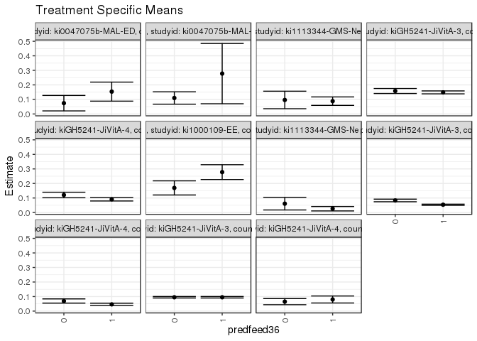

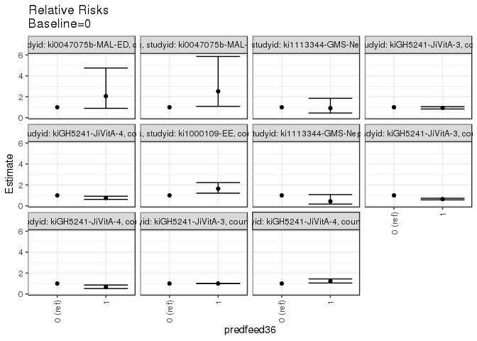

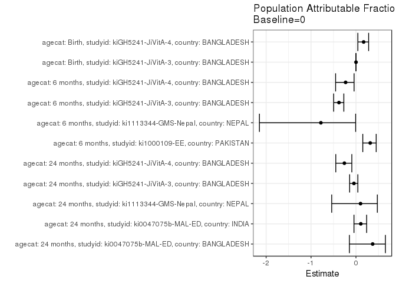

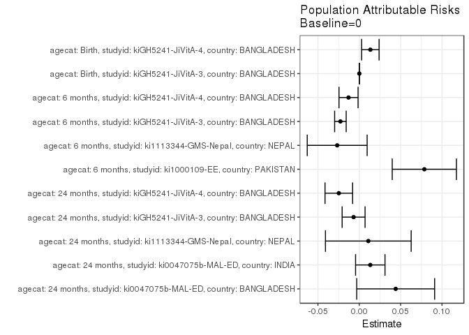

## Results Table

### Parameter: TSM

| agecat | studyid | country | intervention_level | baseline_level | estimate | ci_lower | ci_upper |
| --- | --- | --- | --- | --- | --- | --- | --- |
| Birth | kiGH5241-JiVitA-3 | BANGLADESH | 0 | NA | 0.0950741 | 0.0899741 | 0.1001742 |
| Birth | kiGH5241-JiVitA-3 | BANGLADESH | 1 | NA | 0.0950961 | 0.0899977 | 0.1001945 |
| Birth | kiGH5241-JiVitA-4 | BANGLADESH | 0 | NA | 0.0650189 | 0.0439151 | 0.0861227 |
| Birth | kiGH5241-JiVitA-4 | BANGLADESH | 1 | NA | 0.0798569 | 0.0557590 | 0.1039548 |
| 6 months | ki1000109-EE | PAKISTAN | 0 | NA | 0.1692877 | 0.1207088 | 0.2178666 |
| 6 months | ki1000109-EE | PAKISTAN | 1 | NA | 0.2779918 | 0.2269583 | 0.3290253 |
| 6 months | ki1113344-GMS-Nepal | NEPAL | 0 | NA | 0.0609376 | 0.0176266 | 0.1042486 |
| 6 months | ki1113344-GMS-Nepal | NEPAL | 1 | NA | 0.0263752 | 0.0111368 | 0.0416135 |
| 6 months | kiGH5241-JiVitA-3 | BANGLADESH | 0 | NA | 0.0830819 | 0.0741705 | 0.0919933 |
| 6 months | kiGH5241-JiVitA-3 | BANGLADESH | 1 | NA | 0.0537497 | 0.0497210 | 0.0577784 |
| 6 months | kiGH5241-JiVitA-4 | BANGLADESH | 0 | NA | 0.0693349 | 0.0548756 | 0.0837943 |
| 6 months | kiGH5241-JiVitA-4 | BANGLADESH | 1 | NA | 0.0463362 | 0.0384754 | 0.0541969 |
| 24 months | ki0047075b-MAL-ED | BANGLADESH | 0 | NA | 0.0744681 | 0.0212699 | 0.1276662 |
| 24 months | ki0047075b-MAL-ED | BANGLADESH | 1 | NA | 0.1538462 | 0.0883140 | 0.2193784 |
| 24 months | ki0047075b-MAL-ED | INDIA | 0 | NA | 0.1100478 | 0.0675264 | 0.1525693 |
| 24 months | ki0047075b-MAL-ED | INDIA | 1 | NA | 0.2777778 | 0.0704036 | 0.4851520 |
| 24 months | ki1113344-GMS-Nepal | NEPAL | 0 | NA | 0.0965298 | 0.0363049 | 0.1567547 |
| 24 months | ki1113344-GMS-Nepal | NEPAL | 1 | NA | 0.0883604 | 0.0593096 | 0.1174112 |
| 24 months | kiGH5241-JiVitA-3 | BANGLADESH | 0 | NA | 0.1582129 | 0.1410266 | 0.1753993 |
| 24 months | kiGH5241-JiVitA-3 | BANGLADESH | 1 | NA | 0.1485893 | 0.1384499 | 0.1587288 |
| 24 months | kiGH5241-JiVitA-4 | BANGLADESH | 0 | NA | 0.1206990 | 0.1015519 | 0.1398461 |
| 24 months | kiGH5241-JiVitA-4 | BANGLADESH | 1 | NA | 0.0911026 | 0.0795053 | 0.1026999 |

### Parameter: E(Y)

| agecat | studyid | country | intervention_level | baseline_level | estimate | ci_lower | ci_upper |
| --- | --- | --- | --- | --- | --- | --- | --- |
| Birth | kiGH5241-JiVitA-3 | BANGLADESH | NA | NA | 0.0951527 | 0.0900508 | 0.1002546 |
| Birth | kiGH5241-JiVitA-4 | BANGLADESH | NA | NA | 0.0784044 | 0.0544827 | 0.1023261 |
| 6 months | ki1000109-EE | PAKISTAN | NA | NA | 0.2479564 | 0.2037162 | 0.2921966 |
| 6 months | ki1113344-GMS-Nepal | NEPAL | NA | NA | 0.0342205 | 0.0186698 | 0.0497713 |
| 6 months | kiGH5241-JiVitA-3 | BANGLADESH | NA | NA | 0.0602617 | 0.0561000 | 0.0644233 |
| 6 months | kiGH5241-JiVitA-4 | BANGLADESH | NA | NA | 0.0563414 | 0.0484727 | 0.0642101 |
| 24 months | ki0047075b-MAL-ED | BANGLADESH | NA | NA | 0.1184834 | 0.0747732 | 0.1621936 |
| 24 months | ki0047075b-MAL-ED | INDIA | NA | NA | 0.1233480 | 0.0804760 | 0.1662200 |
| 24 months | ki1113344-GMS-Nepal | NEPAL | NA | NA | 0.1074561 | 0.0790002 | 0.1359121 |
| 24 months | kiGH5241-JiVitA-3 | BANGLADESH | NA | NA | 0.1513522 | 0.1415495 | 0.1611548 |
| 24 months | kiGH5241-JiVitA-4 | BANGLADESH | NA | NA | 0.0959483 | 0.0853397 | 0.1065568 |

### Parameter: RR

| agecat | studyid | country | intervention_level | baseline_level | estimate | ci_lower | ci_upper |
| --- | --- | --- | --- | --- | --- | --- | --- |
| Birth | kiGH5241-JiVitA-3 | BANGLADESH | 0 | 0 | 1.0000000 | 1.0000000 | 1.0000000 |
| Birth | kiGH5241-JiVitA-3 | BANGLADESH | 1 | 0 | 1.0002308 | 0.9997256 | 1.0007362 |
| Birth | kiGH5241-JiVitA-4 | BANGLADESH | 0 | 0 | 1.0000000 | 1.0000000 | 1.0000000 |
| Birth | kiGH5241-JiVitA-4 | BANGLADESH | 1 | 0 | 1.2282113 | 1.0492298 | 1.4377241 |
| 6 months | ki1000109-EE | PAKISTAN | 0 | 0 | 1.0000000 | 1.0000000 | 1.0000000 |
| 6 months | ki1000109-EE | PAKISTAN | 1 | 0 | 1.6421262 | 1.2114954 | 2.2258263 |
| 6 months | ki1113344-GMS-Nepal | NEPAL | 0 | 0 | 1.0000000 | 1.0000000 | 1.0000000 |
| 6 months | ki1113344-GMS-Nepal | NEPAL | 1 | 0 | 0.4328224 | 0.1736399 | 1.0788721 |
| 6 months | kiGH5241-JiVitA-3 | BANGLADESH | 0 | 0 | 1.0000000 | 1.0000000 | 1.0000000 |
| 6 months | kiGH5241-JiVitA-3 | BANGLADESH | 1 | 0 | 0.6469482 | 0.5740697 | 0.7290785 |
| 6 months | kiGH5241-JiVitA-4 | BANGLADESH | 0 | 0 | 1.0000000 | 1.0000000 | 1.0000000 |
| 6 months | kiGH5241-JiVitA-4 | BANGLADESH | 1 | 0 | 0.6682943 | 0.5205725 | 0.8579348 |
| 24 months | ki0047075b-MAL-ED | BANGLADESH | 0 | 0 | 1.0000000 | 1.0000000 | 1.0000000 |
| 24 months | ki0047075b-MAL-ED | BANGLADESH | 1 | 0 | 2.0659341 | 0.8992928 | 4.7460443 |
| 24 months | ki0047075b-MAL-ED | INDIA | 0 | 0 | 1.0000000 | 1.0000000 | 1.0000000 |
| 24 months | ki0047075b-MAL-ED | INDIA | 1 | 0 | 2.5241546 | 1.0890364 | 5.8504530 |
| 24 months | ki1113344-GMS-Nepal | NEPAL | 0 | 0 | 1.0000000 | 1.0000000 | 1.0000000 |
| 24 months | ki1113344-GMS-Nepal | NEPAL | 1 | 0 | 0.9153689 | 0.4516993 | 1.8549956 |
| 24 months | kiGH5241-JiVitA-3 | BANGLADESH | 0 | 0 | 1.0000000 | 1.0000000 | 1.0000000 |
| 24 months | kiGH5241-JiVitA-3 | BANGLADESH | 1 | 0 | 0.9391732 | 0.8370488 | 1.0537572 |
| 24 months | kiGH5241-JiVitA-4 | BANGLADESH | 0 | 0 | 1.0000000 | 1.0000000 | 1.0000000 |
| 24 months | kiGH5241-JiVitA-4 | BANGLADESH | 1 | 0 | 0.7547919 | 0.6190761 | 0.9202597 |

### Parameter: PAR

| agecat | studyid | country | intervention_level | baseline_level | estimate | ci_lower | ci_upper |
| --- | --- | --- | --- | --- | --- | --- | --- |
| Birth | kiGH5241-JiVitA-3 | BANGLADESH | 0 | NA | 0.0000786 | 0.0000429 | 0.0001143 |
| Birth | kiGH5241-JiVitA-4 | BANGLADESH | 0 | NA | 0.0133855 | 0.0028231 | 0.0239479 |
| 6 months | ki1000109-EE | PAKISTAN | 0 | NA | 0.0786687 | 0.0398576 | 0.1174797 |
| 6 months | ki1113344-GMS-Nepal | NEPAL | 0 | NA | -0.0267171 | -0.0629315 | 0.0094973 |
| 6 months | kiGH5241-JiVitA-3 | BANGLADESH | 0 | NA | -0.0228203 | -0.0298027 | -0.0158378 |
| 6 months | kiGH5241-JiVitA-4 | BANGLADESH | 0 | NA | -0.0129935 | -0.0245227 | -0.0014644 |
| 24 months | ki0047075b-MAL-ED | BANGLADESH | 0 | NA | 0.0440153 | -0.0030916 | 0.0911223 |
| 24 months | ki0047075b-MAL-ED | INDIA | 0 | NA | 0.0133002 | -0.0044953 | 0.0310956 |
| 24 months | ki1113344-GMS-Nepal | NEPAL | 0 | NA | 0.0109263 | -0.0408947 | 0.0627474 |
| 24 months | kiGH5241-JiVitA-3 | BANGLADESH | 0 | NA | -0.0068608 | -0.0207208 | 0.0069992 |
| 24 months | kiGH5241-JiVitA-4 | BANGLADESH | 0 | NA | -0.0247507 | -0.0414276 | -0.0080738 |

### Parameter: PAF

| agecat | studyid | country | intervention_level | baseline_level | estimate | ci_lower | ci_upper |
| --- | --- | --- | --- | --- | --- | --- | --- |
| Birth | kiGH5241-JiVitA-3 | BANGLADESH | 0 | NA | 0.0008261 | 0.0004510 | 0.0012010 |
| Birth | kiGH5241-JiVitA-4 | BANGLADESH | 0 | NA | 0.1707240 | 0.0423809 | 0.2818662 |
| 6 months | ki1000109-EE | PAKISTAN | 0 | NA | 0.3172682 | 0.1515611 | 0.4506114 |
| 6 months | ki1113344-GMS-Nepal | NEPAL | 0 | NA | -0.7807322 | -2.1492508 | -0.0069084 |
| 6 months | kiGH5241-JiVitA-3 | BANGLADESH | 0 | NA | -0.3786860 | -0.4962029 | -0.2703993 |
| 6 months | kiGH5241-JiVitA-4 | BANGLADESH | 0 | NA | -0.2306216 | -0.4532565 | -0.0420937 |
| 24 months | ki0047075b-MAL-ED | BANGLADESH | 0 | NA | 0.3714894 | -0.1458350 | 0.6552509 |
| 24 months | ki0047075b-MAL-ED | INDIA | 0 | NA | 0.1078264 | -0.0444316 | 0.2378881 |
| 24 months | ki1113344-GMS-Nepal | NEPAL | 0 | NA | 0.1016819 | -0.5399992 | 0.4759897 |
| 24 months | kiGH5241-JiVitA-3 | BANGLADESH | 0 | NA | -0.0453299 | -0.1410020 | 0.0423202 |
| 24 months | kiGH5241-JiVitA-4 | BANGLADESH | 0 | NA | -0.2579586 | -0.4492123 | -0.0919447 |